# HDS

HealthData Explorers: Alberto Barbesin, Nicolae Bologa, Eleonora Marcassa

```r
library(tidyverse)
```

```r
library(ggplot2)
library(dplyr)
library(corrplot)
library(patchwork)
library(cowplot)
library(survival)
```

# 1 The Datasets

## 1.1 Dataset information

*Sepsis* is a life-threatening condition caused by an exaggerated reaction of the body to an infection, that leads to organ failure or even death. Since *sepsis* can kill a patient even in just one hour, survival prediction is an urgent priority among the medical community: even if laboratory tests and hospital analyses can provide insightful information about the patient, in fact, they might not come in time to allow medical doctors to recognize an immediate death risk and treat it properly. The features of patients that has been recorded at the hospital admission are:

- `sex`,
- `age`,
- `septic episode number`.

We considered a cohort of 110,204 patient admissions.

For the **primary cohort**, the records represent patients with potential sepsis preconditions (according to the pre-Sepsis-3 definition); for the **study cohort**, they represent only patient admissions defined by the new Sepsis-3 definition.

```r
# survival_primary_cohort
(survival_primary_cohort <- read_csv("s41598-020-73558-3_sepsis_survival_primary_cohort.csv") %>%
  rename(age = age_years,
         sex = sex_0male_1female,
         count_episode = episode_number,
         hospital_outcome = hospital_outcome_1alive_0dead) %>%
  mutate(sex_cat = ifelse(sex == 0, "male", "female"), hospital_outcome_cat = ifelse(hospital_outcome == 1, "alive", "dead")))
```

```
## # A tibble: 110,204 × 6
##      age   sex count_episode hospital_outcome sex_cat hospital_outcome_cat
##    <dbl> <dbl>         <dbl>            <dbl> <chr>   <chr>
##  1    21     1             1                1 female  alive
##  2    20     1             1                1 female  alive
##  3    21     1             1                1 female  alive
##  4    77     0             1                1 male    alive
##  5    72     0             1                1 male    alive
##  6    83     0             1                1 male    alive
##  7    74     0             1                1 male    alive
##  8    74     1             1                1 female  alive
##  9    69     0             1                1 male    alive
## 10    53     1             1                1 female  alive
## # ℹ 110,194 more rows
```

```r
# survival_study_cohort
(survival_study_cohort <- read_csv("s41598-020-73558-3_sepsis_survival_study_cohort.csv") %>%
  rename(age = age_years,
         sex = sex_0male_1female,
         count_episode = episode_number,
         hospital_outcome = hospital_outcome_1alive_0dead) %>%
    mutate(sex_cat = ifelse(sex == 0, "male", "female"), hospital_outcome_cat = ifelse(hospital_outcome == 1, "alive", "dead")))
```

```
## # A tibble: 19,051 × 6
##      age   sex count_episode hospital_outcome sex_cat hospital_outcome_cat
##    <dbl> <dbl>         <dbl>            <dbl> <chr>   <chr>
##  1     7     1             1                1 female  alive
##  2    17     0             2                1 male    alive
##  3    70     0             1                1 male    alive
##  4    76     0             1                1 male    alive
##  5     8     0             1                1 male    alive
##  6    41     0             2                1 male    alive
##  7    60     0             1                0 male    dead
##  8    89     1             1                0 female  dead
##  9    76     0             3                0 male    dead
## 10    81     1             1                1 female  alive
## # ℹ 19,041 more rows
```

```r
# survival_validation_cohort
(survival_validation_cohort <- read_csv("s41598-020-73558-3_sepsis_survival_validation_cohort.csv") %>%
  rename(age = age_years,
         sex = sex_0male_1female,
         count_episode = episode_number,
         hospital_outcome = hospital_outcome_1alive_0dead) %>%
    mutate(sex_cat = ifelse(sex == 0, "male", "female"), hospital_outcome_cat = ifelse(hospital_outcome == 1, "alive", "dead")))
```

```
## # A tibble: 137 × 6
##      age   sex count_episode hospital_outcome sex_cat hospital_outcome_cat
##    <dbl> <dbl>         <dbl>            <dbl> <chr>   <chr>
##  1    20     0             1                1 male    alive
##  2    22     0             1                1 male    alive
##  3    26     1             2                0 female  dead
##  4    33     1             1                1 female  alive
##  5    33     0             1                1 male    alive
##  6    33     0             2                0 male    dead
##  7    35     0             1                1 male    alive
##  8    35     1             1                1 female  alive
##  9    36     0             1                1 male    alive
## 10    36     1             1                1 female  alive
## # ℹ 127 more rows
```

A first glance to all the three datasets reveals that the variables `sex` and `hospital_outcome` are binary variables. In order to carry out the analysis, it can be helpful converting them in categorical variables.

# 2 Exploratory Analysis

## 2.1 Survival primary cohort

### 2.1.1 Structure and summary of data and some exploratory plots

```r
str(survival_primary_cohort)
```

```
## tibble [110,204 × 6] (S3: tbl_df/tbl/data.frame)
##  $ age                 : num [1:110204] 21 20 21 77 72 83 74 74 69 53 ...
##  $ sex                 : num [1:110204] 1 1 1 0 0 0 0 1 0 1 ...
##  $ count_episode       : num [1:110204] 1 1 1 1 1 1 1 1 1 1 ...
##  $ hospital_outcome    : num [1:110204] 1 1 1 1 1 1 1 1 1 1 ...
##  $ sex_cat             : chr [1:110204] "female" "female" "female" "male" ...
##  $ hospital_outcome_cat: chr [1:110204] "alive" "alive" "alive" "alive" ...
```

```r
summary(survival_primary_cohort[!(colnames(survival_primary_cohort) %in% c("sex_cat", "hospital_outcome_cat"))])
```

```
##       age              sex         count_episode   hospital_outcome
##  Min.   :  0.00   Min.   :0.0000   Min.   :1.000   Min.   :0.0000
##  1st Qu.: 51.00   1st Qu.:0.0000   1st Qu.:1.000   1st Qu.:1.0000
##  Median : 68.00   Median :0.0000   Median :1.000   Median :1.0000
##  Mean   : 62.74   Mean   :0.4739   Mean   :1.349   Mean   :0.9265
##  3rd Qu.: 81.00   3rd Qu.:1.0000   3rd Qu.:1.000   3rd Qu.:1.0000
##  Max.   :100.00   Max.   :1.0000   Max.   :5.000   Max.   :1.0000
```

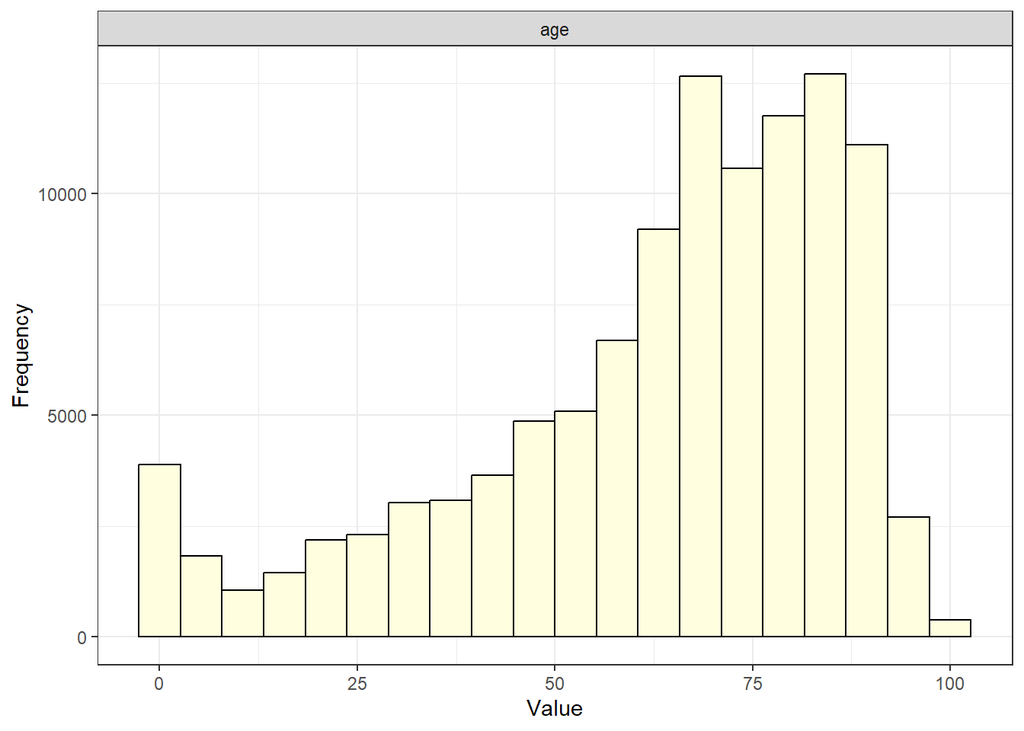

```r
survival_primary_cohort %>%
  select(age) %>%
  gather(cols, value) %>%
  ggplot(aes(x = value)) +
  geom_histogram(bins = 20, fill = "lightyellow", col = "black") +
  facet_wrap(.~ cols, ncol = 1) +
  labs(x = "Value", y = "Frequency") +
  theme_bw()
```

This very first graph highlights the fact the data collected belong mostly to older patients. As a matter of fact, the distribution is *left skewed*.

```r
survival_primary_cohort %>%
  group_by(sex_cat) %>%
  summarise(n = n(), mean= n/length(survival_primary_cohort$sex_cat))
```

```
## # A tibble: 2 × 3
##   sex_cat     n  mean
##   <chr>   <int> <dbl>
## 1 female  52231 0.474
## 2 male    57973 0.526
```

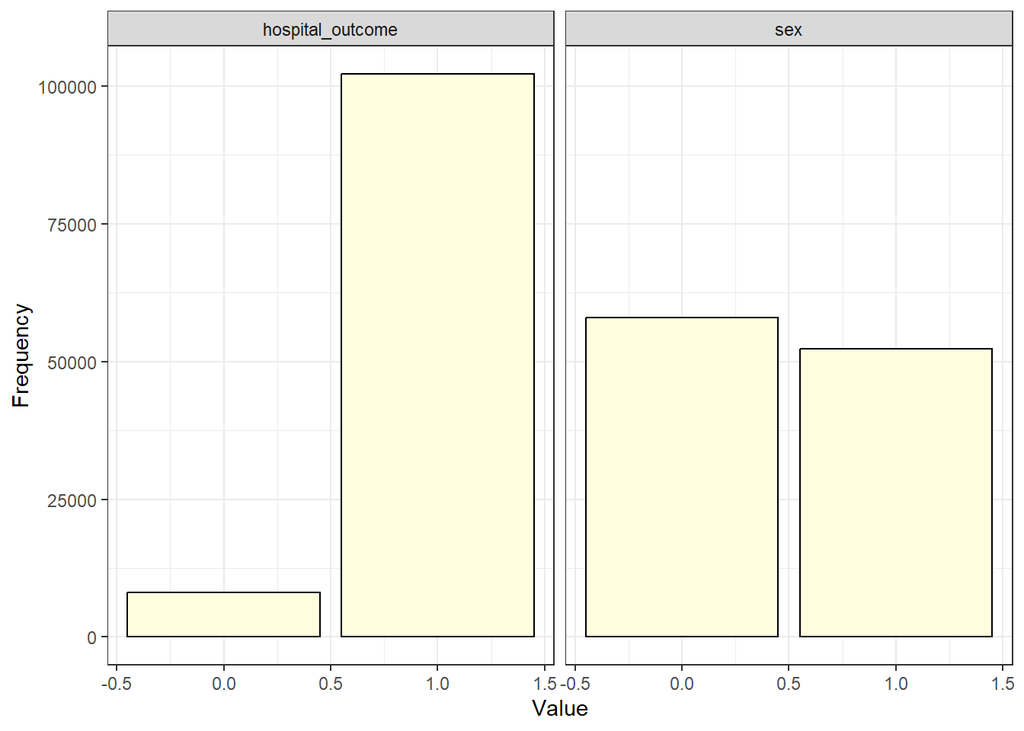

```r
survival_primary_cohort %>%
  select(sex, hospital_outcome) %>%
  gather(cols, value) %>%
  ggplot(aes(x = value)) +
  geom_bar(fill = "lightyellow", col = "black") +
  facet_wrap(.~ cols, ncol = 2) +
  labs(x = "Value", y = "Frequency") +
  theme_bw()
```

The graph representing `hospital_outcome` reveals a low mortality rate among patients affected by sepsis, with the majority surviving.  
Furthermore, analysis of the `sex` variable indicates a higher proportion of male patients compared to females, as showed in the accompanying table.

```r
survival_primary_cohort %>% group_by(sex) %>% summarise(m_age = mean(age), sd_age = sd(age), freq = n()) %>% arrange(desc(sex))
```

```
## # A tibble: 2 × 4
##     sex m_age sd_age  freq
##   <dbl> <dbl>  <dbl> <int>
## 1     1  62.2   25.2 52231
## 2     0  63.3   23.1 57973
```

```r
spc_by_age <- survival_primary_cohort %>% group_by(age) %>% summarise(m_sex = mean(sex), sd_sex = sd(sex), freq = n()) %>% arrange(desc(freq))
```

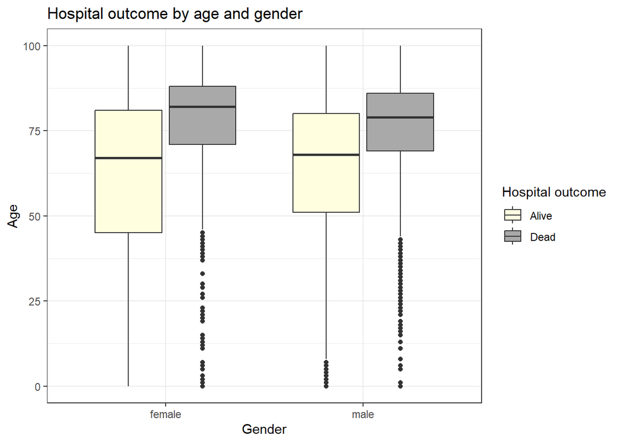

```r
survival_primary_cohort %>%
  ggplot(aes(x = sex_cat, y = age, fill = hospital_outcome_cat)) +
  geom_boxplot(show.legend = TRUE) +
  labs(title = "Hospital outcome by age and gender", x = "Gender", y = "Age", fill = "Hospital outcome")+
  scale_fill_manual(values = c("alive" = "lightyellow", "dead" = "darkgrey"),
                    labels = c("Alive", "Dead")) +
  theme_bw()
```

The dataset is splitted into two parts, in order to better distinguish *survived* and *dead* people.

```r
dead_survival_primary_cohort <- survival_primary_cohort%>%
filter(hospital_outcome_cat=="dead" & hospital_outcome==0)
dead_survival_primary_cohort
```

```
## # A tibble: 8,105 × 6
##      age   sex count_episode hospital_outcome sex_cat hospital_outcome_cat
##    <dbl> <dbl>         <dbl>            <dbl> <chr>   <chr>
##  1    72     0             1                0 male    dead
##  2    63     0             1                0 male    dead
##  3    89     1             2                0 female  dead
##  4    80     0             3                0 male    dead
##  5    62     1             3                0 female  dead
##  6    56     1             3                0 female  dead
##  7    63     0             1                0 male    dead
##  8    60     0             1                0 male    dead
##  9    89     1             1                0 female  dead
## 10    61     0             1                0 male    dead
## # ℹ 8,095 more rows
```

```r
survived_survival_primary_cohort <- survival_primary_cohort%>%
filter(hospital_outcome_cat=="alive" & hospital_outcome==1)
survived_survival_primary_cohort
```

```
## # A tibble: 102,099 × 6
##      age   sex count_episode hospital_outcome sex_cat hospital_outcome_cat
##    <dbl> <dbl>         <dbl>            <dbl> <chr>   <chr>
##  1    21     1             1                1 female  alive
##  2    20     1             1                1 female  alive
##  3    21     1             1                1 female  alive
##  4    77     0             1                1 male    alive
##  5    72     0             1                1 male    alive
##  6    83     0             1                1 male    alive
##  7    74     0             1                1 male    alive
##  8    74     1             1                1 female  alive
##  9    69     0             1                1 male    alive
## 10    53     1             1                1 female  alive
## # ℹ 102,089 more rows
```

```r
(n_episodes <- survived_survival_primary_cohort%>%
group_by(count_episode)%>%
summarise(n = n()))
```

```
## # A tibble: 5 × 2
##   count_episode     n
##           <dbl> <int>
## 1             1 78747
## 2             2 15285
## 3             3  4996
## 4             4  2036
## 5             5  1035
```

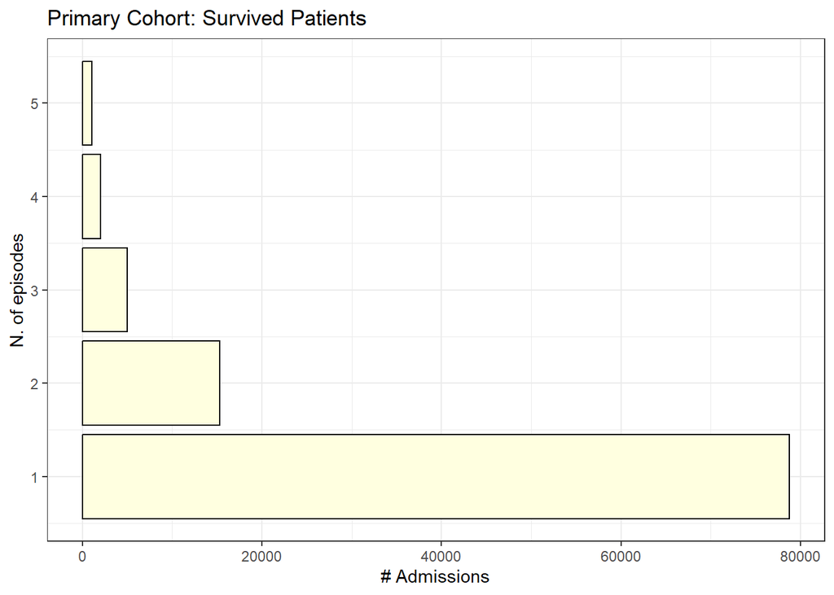

```r
ggplot(n_episodes, aes(x = count_episode, y = n)) +
  geom_bar(stat = "identity", fill = "lightyellow", color = "black") +
  labs(y = "# Admissions", x = "N. of episodes", title = "Primary Cohort: Survived Patients") +
  theme_bw() +
  coord_flip()
```

Thanks to a combined reading of the previously presented tables and this last graph, it can be understood that the majority of the people had just one episode of *sepsis*. As a matter of fact, this one and only episode involve about 80,000 people. This number fastly decrease: “just” 15,000 people showed two episodes of *sepsis*. The greater the number of episodes the lower is the number of people who presented the infection: it gets lower than 5,000.

Keep in mind that these number represent all the people who got affected by the disease but survived.

While the following results are about people who got the infection but died.

```r
(n_episodes <- dead_survival_primary_cohort%>%
group_by(count_episode)%>%
summarise(n = n()))
```

```
## # A tibble: 5 × 2
##   count_episode     n
##           <dbl> <int>
## 1             1  6064
## 2             2  1403
## 3             3   407
## 4             4   163
## 5             5    68
```

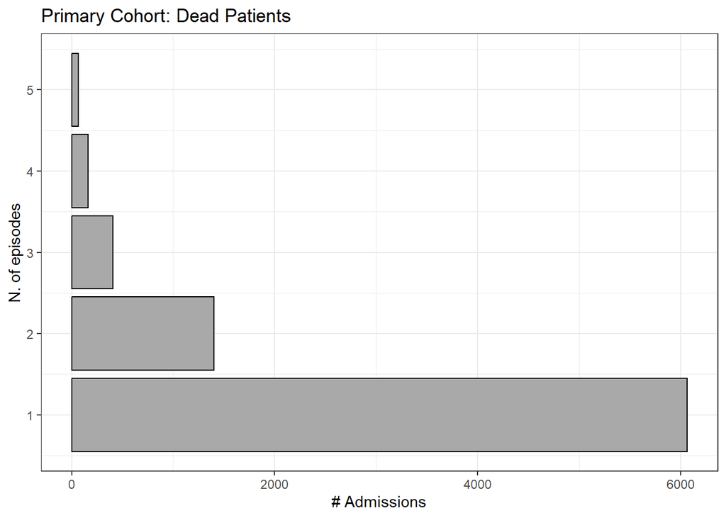

```r
ggplot(data = n_episodes, aes(x = count_episode, y = n)) +
  geom_bar(stat = "identity", fill = "darkgrey", color = "black") +
  labs(y = "# Admissions", x = "N. of episodes", title = "Primary Cohort: Dead Patients") +
  theme_bw() +
  coord_flip()
```

In this case, the number of dead people who showed just one case of *sepsis* is around 6,000. Then the number decreases to c.a. 1,500 when the episodes increase at 2. As before, the greater the number of episodes the lower the number of infected patients who died.

### 2.1.2 Probability of getting sepsis

We are interested in determining whether men with *sepsis* tend to be older than women, and vice versa. Additionally, we are exploring whether there is a gender and age-related difference in survival likelihood.

```r
male = survival_primary_cohort %>% filter(sex == 0)
female = survival_primary_cohort %>% filter(sex == 1)

m_mean_age = mean(male$age)
m_sd_age = sd(male$age)
f_mean_age = mean(female$age)
f_sd_age = sd(female$age)

# males' age average
m_mean_age
```

```
## [1] 63.25243
```

```r
# males' age standard deviation
m_sd_age
```

```
## [1] 23.14269
```

```r
# females' age average
f_mean_age
```

```
## [1] 62.16123
```

```r
# females' age standard deviation
f_sd_age
```

```
## [1] 25.16188
```

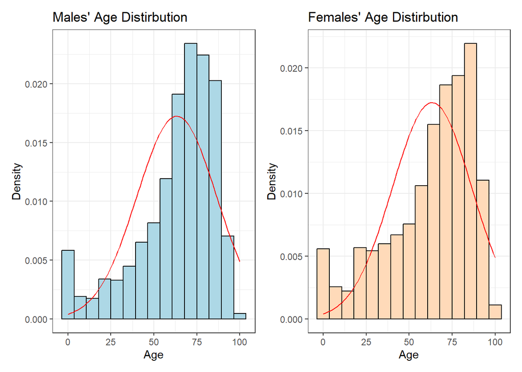

```r
plot_male <- ggplot(male) +
  geom_histogram(aes(x = age, y = after_stat(density)), bins = 15, fill = "lightblue", color = "black") +
  stat_function(fun = dnorm, args = list (mean = m_mean_age, sd = m_sd_age), color = "red") +
  labs(title = "Males' Age Distirbution", x = "Age", y = "Density") +
  theme_bw()

plot_female <- ggplot(female) +
  geom_histogram(aes(x = age, y = after_stat(density)), bins = 15, fill = "#FFDAB9", color = "black") +
  stat_function(fun = dnorm, args = list (mean = m_mean_age, sd = m_sd_age), color = "red") +
  labs(title = "Females' Age Distirbution", x = "Age", y = "Density") +
  theme_bw()

(combined_plots <- plot_male + plot_female + plot_layout(ncol = 2))
```

Building upon our initial observations, individuals affected by *sepsis* tend to be older, as evidenced by the continued presence of a *left-skewed* distribution. Now, let’s look at whether men and women under 81, which is younger than the third quantile, are more likely to get sepsis according.

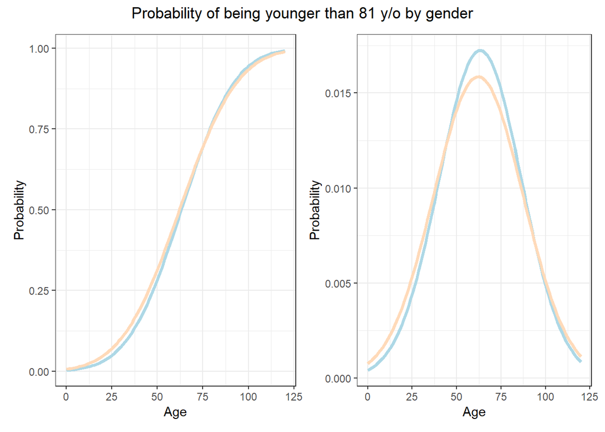

```r
# probability males are younger than 81
prob_males <- pnorm(quantile(survival_primary_cohort$age, probs = 0.75), m_mean_age, m_sd_age, lower.tail = T)
# probability females are younger than 81
prob_females <-pnorm(quantile(survival_primary_cohort$age, probs = 0.75), f_mean_age, f_sd_age, lower.tail = T)

probs_df <- data.frame(age = seq(0,120, by = 1),
                       prob_males = pnorm(seq(0,120,by=1), m_mean_age, m_sd_age, lower.tail = T),
                       prob_females = pnorm(seq(0,120,by=1), f_mean_age, f_sd_age, lower.tail = T))

pnorm_plot <- ggplot(probs_df, aes(x = age)) +
  stat_function(fun = pnorm, args = list(mean = m_mean_age, sd = m_sd_age), color = "lightblue", linewidth = 1.3) +
  stat_function(fun = pnorm, args = list(mean = f_mean_age, sd = f_sd_age), color = "#FFDAB9", linewidth = 1.3) +
  labs(x = "Age", y="Probability") +
  theme_bw()

dnorm_plot <- ggplot(probs_df, aes(x = age)) +
  stat_function(fun = dnorm, args = list(mean = m_mean_age, sd = m_sd_age), color = "lightblue", linewidth = 1.3) +
  stat_function(fun = dnorm, args = list(mean = f_mean_age, sd = f_sd_age), color = "#FFDAB9", linewidth = 1.3) +
  labs(x = "Age", y="Probability") +
  theme_bw()

(combined_plots <- plot_grid(pnorm_plot, dnorm_plot, ncol = 2, align = "h") +
                  plot_annotation(title = "Probability of being younger than 81 y/o by gender", theme = theme(plot.title = element_text(hjust = 0.5))))
```

Once computed the probability of getting the *sepsis* infection, it is possible to affirm that the 77,30% of women and the 77,84% of men younger than the age third quantile get the infection at least one time. So quite similar probabilities for both women and men.

Do they have the same probability of death if they are younger than the third quantile?

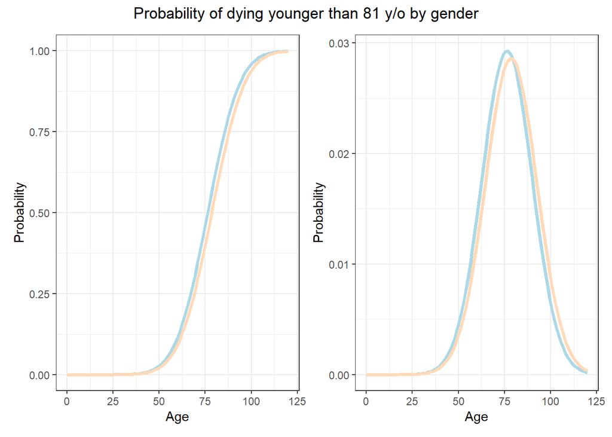

```r
male_dead = survival_primary_cohort %>% filter(sex == 0 & hospital_outcome == 0)
female_dead = survival_primary_cohort %>% filter(sex == 1 & hospital_outcome == 0)

md_mean_age = mean(male_dead$age)
md_sd_age = sd(male_dead$age)
fd_mean_age = mean(female_dead$age)
fd_sd_age = sd(female_dead$age)

# probability males who died of sepsis are younger than 81
prob_males <- pnorm(quantile(survival_primary_cohort$age, probs = 0.75), md_mean_age, md_sd_age, lower.tail = T)
# probability females who died of sepsis are younger than 81
prob_females <- pnorm(quantile(survival_primary_cohort$age, probs = 0.75), fd_mean_age, fd_sd_age, lower.tail = T)

probs_df <- data.frame(age = seq(0, 120, by = 1),
                       prob_males = pnorm(seq(0, 120, by = 1), md_mean_age, md_sd_age, lower.tail = TRUE),
                       prob_females = pnorm(seq(0, 120, by = 1), fd_mean_age, fd_sd_age, lower.tail = TRUE))


pnorm_plot <- ggplot(data = probs_df, aes(x = age)) +
  stat_function(fun = pnorm, args = list(mean = md_mean_age, sd = md_sd_age), color = "lightblue", linewidth = 1.3) +
  stat_function(fun = pnorm, args = list(mean = fd_mean_age, sd = fd_sd_age), color = "#FFDAB9", linewidth= 1.3) +
  labs(x = "Age", y = "Probability") +
  theme_bw()

dnorm_plot <- ggplot(data = probs_df, aes(x = age)) +
  stat_function(fun = dnorm, args = list(mean = md_mean_age, sd = md_sd_age), color = "lightblue", linewidth = 1.3) +
  stat_function(fun = dnorm, args = list(mean = fd_mean_age, sd = fd_sd_age), color = "#FFDAB9", linewidth = 1.3) +
  labs(x = "Age", y = "Probability") +
  theme_bw()

(combined_plots <- plot_grid(pnorm_plot, dnorm_plot, ncol =2, align = "h") +
    plot_annotation(title = "Probability of dying younger than 81 y/o by gender", theme = theme(plot.title = element_text(hjust = 0.5))))
```

Relying upon this probabilities, men younger than 81 are more likely to get *sepsis* before in life time than women. As a matter of fact, women who get infected before the third quantile age are the 57.03% of the total feminine population; while men are the 63.39% of the total masculine population.

## 2.2 Survival study cohort

```r
survival_study_cohort
```

```
## # A tibble: 19,051 × 6
##      age   sex count_episode hospital_outcome sex_cat hospital_outcome_cat
##    <dbl> <dbl>         <dbl>            <dbl> <chr>   <chr>
##  1     7     1             1                1 female  alive
##  2    17     0             2                1 male    alive
##  3    70     0             1                1 male    alive
##  4    76     0             1                1 male    alive
##  5     8     0             1                1 male    alive
##  6    41     0             2                1 male    alive
##  7    60     0             1                0 male    dead
##  8    89     1             1                0 female  dead
##  9    76     0             3                0 male    dead
## 10    81     1             1                1 female  alive
## # ℹ 19,041 more rows
```

```r
str(survival_study_cohort)
```

```
## tibble [19,051 × 6] (S3: tbl_df/tbl/data.frame)
##  $ age                 : num [1:19051] 7 17 70 76 8 41 60 89 76 81 ...
##  $ sex                 : num [1:19051] 1 0 0 0 0 0 0 1 0 1 ...
##  $ count_episode       : num [1:19051] 1 2 1 1 1 2 1 1 3 1 ...
##  $ hospital_outcome    : num [1:19051] 1 1 1 1 1 1 0 0 0 1 ...
##  $ sex_cat             : chr [1:19051] "female" "male" "male" "male" ...
##  $ hospital_outcome_cat: chr [1:19051] "alive" "alive" "alive" "alive" ...
```

```r
summary(survival_study_cohort)
```

```
##       age             sex         count_episode   hospital_outcome
##  Min.   :  0.0   Min.   :0.0000   Min.   :1.000   Min.   :0.0000
##  1st Qu.: 65.0   1st Qu.:0.0000   1st Qu.:1.000   1st Qu.:1.0000
##  Median : 77.0   Median :0.0000   Median :1.000   Median :1.0000
##  Mean   : 72.5   Mean   :0.4486   Mean   :1.396   Mean   :0.8107
##  3rd Qu.: 85.0   3rd Qu.:1.0000   3rd Qu.:2.000   3rd Qu.:1.0000
##  Max.   :100.0   Max.   :1.0000   Max.   :5.000   Max.   :1.0000
##    sex_cat          hospital_outcome_cat
##  Length:19051       Length:19051
##  Class :character   Class :character
##  Mode  :character   Mode  :character
##
##
##
```

```r
#summary(survival_study_cohort[!(colnames(survival_primary_cohort) %in% c("sex_cat", "hospital_outcome_cat"))])
```

As already did for the previous dataset, the following one is split into two too: *survived* and *dead* people.

```r
(survived_survival_study_cohort <- survival_study_cohort%>%
   filter(hospital_outcome_cat=="alive" & hospital_outcome==1))
```

```
## # A tibble: 15,445 × 6
##      age   sex count_episode hospital_outcome sex_cat hospital_outcome_cat
##    <dbl> <dbl>         <dbl>            <dbl> <chr>   <chr>
##  1     7     1             1                1 female  alive
##  2    17     0             2                1 male    alive
##  3    70     0             1                1 male    alive
##  4    76     0             1                1 male    alive
##  5     8     0             1                1 male    alive
##  6    41     0             2                1 male    alive
##  7    81     1             1                1 female  alive
##  8    55     0             1                1 male    alive
##  9    33     1             2                1 female  alive
## 10    48     0             1                1 male    alive
## # ℹ 15,435 more rows
```

```r
(dead_survival_study_cohort <- survival_study_cohort%>%
   filter(hospital_outcome==0 & hospital_outcome_cat =="dead"))
```

```
## # A tibble: 3,606 × 6
##      age   sex count_episode hospital_outcome sex_cat hospital_outcome_cat
##    <dbl> <dbl>         <dbl>            <dbl> <chr>   <chr>
##  1    60     0             1                0 male    dead
##  2    89     1             1                0 female  dead
##  3    76     0             3                0 male    dead
##  4    66     1             1                0 female  dead
##  5    63     0             2                0 male    dead
##  6    73     0             2                0 male    dead
##  7    66     0             1                0 male    dead
##  8    79     1             1                0 female  dead
##  9    87     1             1                0 female  dead
## 10    59     0             1                0 male    dead
## # ℹ 3,596 more rows
```

```r
(n_episodes <- survived_survival_study_cohort%>%
group_by(count_episode)%>%
summarise(n = n()))
```

```
## # A tibble: 5 × 2
##   count_episode     n
##           <dbl> <int>
## 1             1 11332
## 2             2  2681
## 3             3   893
## 4             4   374
## 5             5   165
```

```r
plot_survived <- ggplot(data = n_episodes, aes(x = count_episode, y = n)) +
  geom_bar(stat = "identity", fill = "lightyellow", color = "black") +
  labs(title = "Study Cohort: Survived Patients", y = "# Admissions", x = "N. of episodes") +
  theme_bw() +
  coord_flip()

(n_episodes <- dead_survival_study_cohort%>%
group_by(count_episode)%>%
summarise(n = n()))
```

```
## # A tibble: 5 × 2
##   count_episode     n
##           <dbl> <int>
## 1             1  2710
## 2             2   623
## 3             3   174
## 4             4    67
## 5             5    32
```

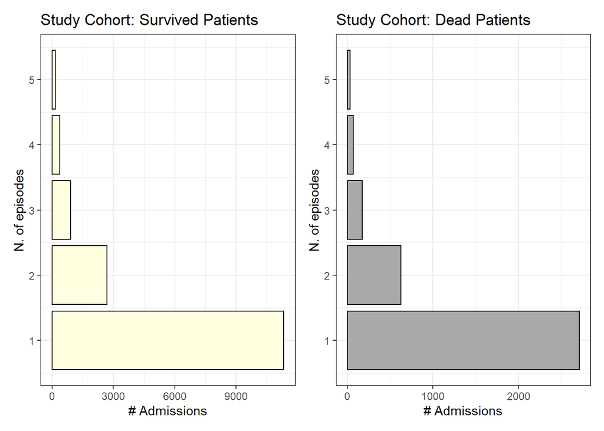

```r
plot_dead <- ggplot( n_episodes, aes(x = count_episode, y = n)) +
  geom_bar(stat = "identity", color = "black", fill = "darkgrey") +
  labs(title = "Study Cohort: Dead Patients", y = "# Admissions", x = "N. of episodes") +
  theme_bw() +
  coord_flip()

(combined_plots <- plot_survived + plot_dead + plot_layout(ncol = 2))
```

By looking at the plots, it is possible to notice that even in the `survival_study_cohort`, distinguished in *survived* and *dead*, the behavior of the data is the same as the one previously seen: the greater the `N. of episodes`, the lower is the `# Admissions`.

```r
numerical_data_study <- survival_study_cohort[, sapply(survival_study_cohort, is.numeric)]
numerical_data_study
```

```
## # A tibble: 19,051 × 4
##      age   sex count_episode hospital_outcome
##    <dbl> <dbl>         <dbl>            <dbl>
##  1     7     1             1                1
##  2    17     0             2                1
##  3    70     0             1                1
##  4    76     0             1                1
##  5     8     0             1                1
##  6    41     0             2                1
##  7    60     0             1                0
##  8    89     1             1                0
##  9    76     0             3                0
## 10    81     1             1                1
## # ℹ 19,041 more rows
```

```r
cor(numerical_data_study)
```

```
##                          age         sex count_episode hospital_outcome
## age               1.00000000  0.06393699   -0.06829214      -0.12617415
## sex               0.06393699  1.00000000   -0.03964150       0.01524892
## count_episode    -0.06829214 -0.03964150    1.00000000       0.02203592
## hospital_outcome -0.12617415  0.01524892    0.02203592       1.00000000
```

While computing the correlation between variables in the dataset, it can be concluded that there isn’t a strong relationship.

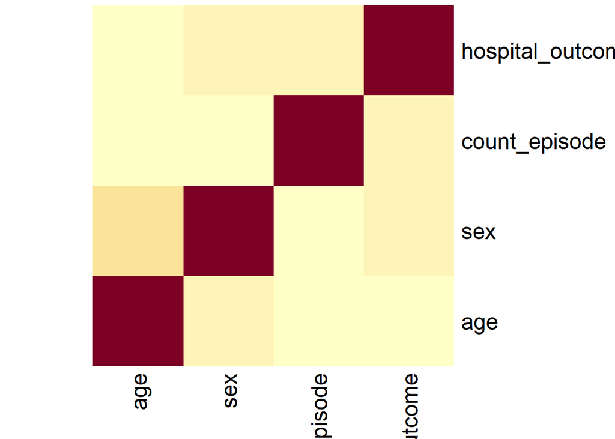

```r
corr_matrix_study = cor(numerical_data_study)
heatmap(corr_matrix_study,Colv = NA, Rowv = NA, scale="column")
```

## 2.3 Survival validation

```r
str(survival_validation_cohort)
```

```
## tibble [137 × 6] (S3: tbl_df/tbl/data.frame)
##  $ age                 : num [1:137] 20 22 26 33 33 33 35 35 36 36 ...
##  $ sex                 : num [1:137] 0 0 1 1 0 0 0 1 0 1 ...
##  $ count_episode       : num [1:137] 1 1 2 1 1 2 1 1 1 1 ...
##  $ hospital_outcome    : num [1:137] 1 1 0 1 1 0 1 1 1 1 ...
##  $ sex_cat             : chr [1:137] "male" "male" "female" "female" ...
##  $ hospital_outcome_cat: chr [1:137] "alive" "alive" "dead" "alive" ...
```

```r
summary(survival_validation_cohort[!(colnames(survival_primary_cohort) %in% c("sex_cat", "hospital_outcome_cat"))])
```

```
##       age             sex         count_episode   hospital_outcome
##  Min.   :20.00   Min.   :0.0000   Min.   :1.000   Min.   :0.0000
##  1st Qu.:50.00   1st Qu.:0.0000   1st Qu.:1.000   1st Qu.:1.0000
##  Median :60.00   Median :0.0000   Median :1.000   Median :1.0000
##  Mean   :59.54   Mean   :0.3431   Mean   :1.161   Mean   :0.8248
##  3rd Qu.:72.00   3rd Qu.:1.0000   3rd Qu.:1.000   3rd Qu.:1.0000
##  Max.   :89.00   Max.   :1.0000   Max.   :2.000   Max.   :1.0000
```

Here we can see that `age` is strongly symmetrical. While, the `count_episode` seems to be just quite symmetrical.

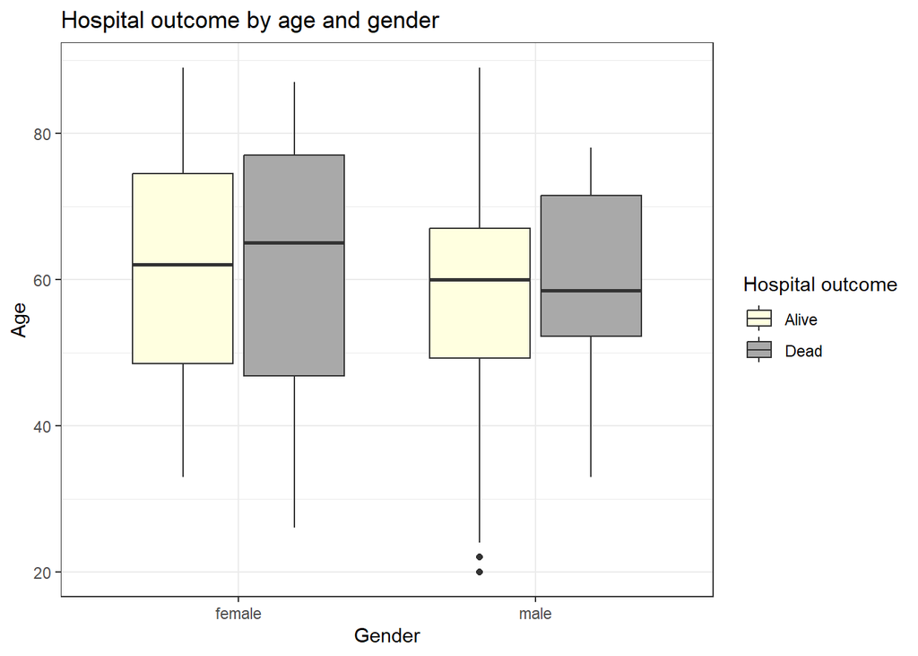

```r
(survival_validation_cohort %>%
  ggplot(aes(x = sex_cat, y = age, fill = hospital_outcome_cat)) +
  geom_boxplot(show.legend = TRUE) +
  labs(title = "Hospital outcome by age and gender", x = "Gender", y = "Age", fill = "Hospital outcome")+
  scale_fill_manual(values = c("alive" = "lightyellow", "dead" = "darkgrey"),
                    labels = c("Alive", "Dead")) +
  theme_bw())
```

```r
survived_survival_study_cohort <- survival_study_cohort%>%
filter(hospital_outcome_cat=="alive" & hospital_outcome==1)
survived_survival_study_cohort
```

```
## # A tibble: 15,445 × 6
##      age   sex count_episode hospital_outcome sex_cat hospital_outcome_cat
##    <dbl> <dbl>         <dbl>            <dbl> <chr>   <chr>
##  1     7     1             1                1 female  alive
##  2    17     0             2                1 male    alive
##  3    70     0             1                1 male    alive
##  4    76     0             1                1 male    alive
##  5     8     0             1                1 male    alive
##  6    41     0             2                1 male    alive
##  7    81     1             1                1 female  alive
##  8    55     0             1                1 male    alive
##  9    33     1             2                1 female  alive
## 10    48     0             1                1 male    alive
## # ℹ 15,435 more rows
```

```r
dead_survival_study_cohort <- survival_study_cohort%>%
filter(hospital_outcome==0 & hospital_outcome_cat =="dead")
dead_survival_study_cohort
```

```
## # A tibble: 3,606 × 6
##      age   sex count_episode hospital_outcome sex_cat hospital_outcome_cat
##    <dbl> <dbl>         <dbl>            <dbl> <chr>   <chr>
##  1    60     0             1                0 male    dead
##  2    89     1             1                0 female  dead
##  3    76     0             3                0 male    dead
##  4    66     1             1                0 female  dead
##  5    63     0             2                0 male    dead
##  6    73     0             2                0 male    dead
##  7    66     0             1                0 male    dead
##  8    79     1             1                0 female  dead
##  9    87     1             1                0 female  dead
## 10    59     0             1                0 male    dead
## # ℹ 3,596 more rows
```

```r
(n_episodes <- survived_survival_study_cohort%>%
group_by(count_episode)%>%
summarise(n = n()))
```

```
## # A tibble: 5 × 2
##   count_episode     n
##           <dbl> <int>
## 1             1 11332
## 2             2  2681
## 3             3   893
## 4             4   374
## 5             5   165
```

```r
plot_survived <- ggplot(data = n_episodes, aes(x = count_episode, y = n)) +
  geom_bar(stat = "identity", fill = "lightyellow", color = "black") +
  labs(title = "Study Cohort: Survived Patients", y = "# Admissions", x = "N. of episodes") +
  theme_bw() +
  coord_flip()

(n_episodes <- dead_survival_study_cohort%>%
group_by(count_episode)%>%
summarise(n = n()))
```

```
## # A tibble: 5 × 2
##   count_episode     n
##           <dbl> <int>
## 1             1  2710
## 2             2   623
## 3             3   174
## 4             4    67
## 5             5    32
```

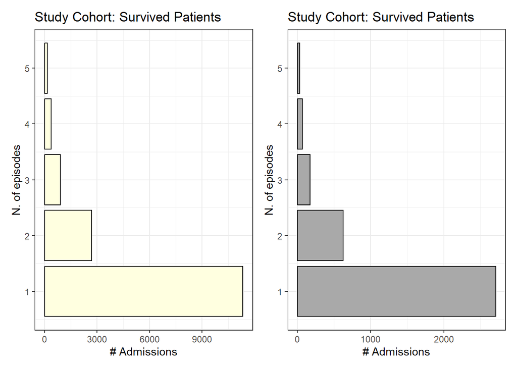

```r
plot_dead<- ggplot(data = n_episodes, aes(x = count_episode, y = n)) +
  geom_bar(stat = "identity", fill = "darkgrey", color = "black") +
  labs(title = "Study Cohort: Survived Patients", y = "# Admissions", x = "N. of episodes") +
  theme_bw() +
  coord_flip()

(combined_plots <- plot_survived + plot_dead + plot_layout(ncol = 2))
```

```r
numerical_data_study <- survival_study_cohort[, sapply(survival_study_cohort, is.numeric)]
numerical_data_study
```

```
## # A tibble: 19,051 × 4
##      age   sex count_episode hospital_outcome
##    <dbl> <dbl>         <dbl>            <dbl>
##  1     7     1             1                1
##  2    17     0             2                1
##  3    70     0             1                1
##  4    76     0             1                1
##  5     8     0             1                1
##  6    41     0             2                1
##  7    60     0             1                0
##  8    89     1             1                0
##  9    76     0             3                0
## 10    81     1             1                1
## # ℹ 19,041 more rows
```

```r
cor(numerical_data_study)
```

```
##                          age         sex count_episode hospital_outcome
## age               1.00000000  0.06393699   -0.06829214      -0.12617415
## sex               0.06393699  1.00000000   -0.03964150       0.01524892
## count_episode    -0.06829214 -0.03964150    1.00000000       0.02203592
## hospital_outcome -0.12617415  0.01524892    0.02203592       1.00000000
```

The computed correlation shows that there isn’t a strong relationship between the variables.

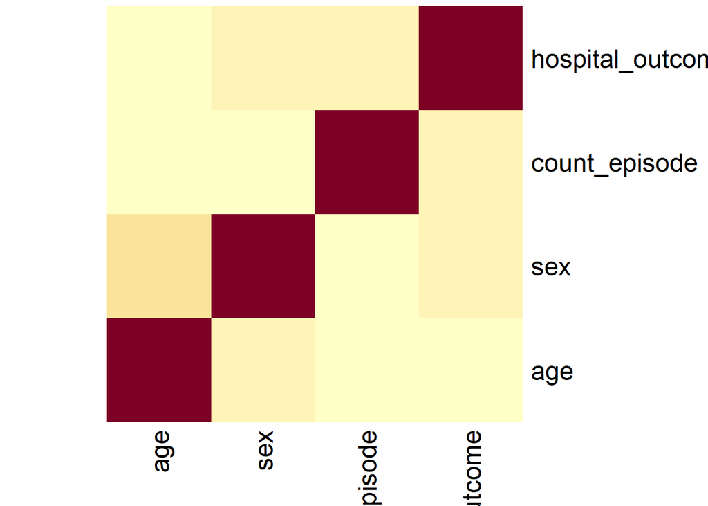

```r
corr_matrix_study = cor(numerical_data_study)
heatmap(corr_matrix_study,Colv = NA, Rowv = NA, scale="column")
```

# 3 Sampling methods

```r
table(survival_primary_cohort$hospital_outcome)
```

```
##
##      0      1
##   8105 102099
```

```r
library("smotefamily")
library("caret")
survival_primary_cohort <- survival_primary_cohort%>%
select(age,sex,count_episode,hospital_outcome)
```

```r
survival_primary_cohort$hospital_outcome <- as.factor(survival_primary_cohort$hospital_outcome)
survival_primary_cohort$sex <- as.factor(survival_primary_cohort$sex)
survival_primary_cohort$count_episode <- as.factor(survival_primary_cohort$count_episode)
```

```r
library(modeldata)
library(recipes)
```

# 4 Logistic Regression

We want to fit a model of $logistic$ $regression$ of this type:
$$p(x) = Pr(\text{hospital_outcome} = 0 |
\text{age} = x) = \frac{e^{\beta_0+\beta_1x}}{1 + e^{\beta_0+\beta_1x}}$$

## 4.1 Adjusting the Loss Function

We increase the weights of the minority class for the loss function. Then when we fit the $logistic$ $regression$ model, we specify the resulting weights in the parameter $weights$.

- `table(target_variable)` calculates the frequency of each class in the binary target variable.
- `prop.table(class_freq)` calculates the proportions of each class frequency relative to the total number of observations.
- `1 / prop.table(class_freq)` calculates the inverse of the proportions to create class weights. The less frequent class (minority class) will have a higher weight, while the more frequent class (majority class) will have a lower weight.

```r
class_freq <- table(survival_primary_cohort$hospital_outcome) # calculates the frequency of each class in the binary target variable.

# Calculate class weights
class_weights <- 1 / prop.table(class_freq)
# calculates the inverse of the proportions to create class weights.
class_weights <- round(class_weights, digits = 5)

class_weights
```

```
##
##        0        1
## 13.59704  1.07938
```

```r
survival_primary_cohort
```

```
## # A tibble: 110,204 × 4
##      age sex   count_episode hospital_outcome
##    <dbl> <fct> <fct>         <fct>
##  1    21 1     1             1
##  2    20 1     1             1
##  3    21 1     1             1
##  4    77 0     1             1
##  5    72 0     1             1
##  6    83 0     1             1
##  7    74 0     1             1
##  8    74 1     1             1
##  9    69 0     1             1
## 10    53 1     1             1
## # ℹ 110,194 more rows
```

```r
#model_weighted_loss_function <- glm(hospital_outcome ~ ., data = survival_primary_cohort, family = binomial, weights = class_weights)
#model_weighted_loss_function
```

## 4.2 Smote

```r
#newData <- SMOTE(hospital_outcome ~ ., survival_primary_cohort, perc.over = 80000, perc.under=400000)
#table(newData$hospital_outcome_cat)
```

## 4.3 Undersampling

```r
sampled_data <- survival_primary_cohort[sample(nrow(survival_primary_cohort), 8105), ]
sampled_data
```

```
## # A tibble: 8,105 × 4
##      age sex   count_episode hospital_outcome
##    <dbl> <fct> <fct>         <fct>
##  1    90 1     1             1
##  2    67 0     1             1
##  3    50 1     1             1
##  4    68 0     1             1
##  5    49 1     1             1
##  6    75 0     2             1
##  7    93 1     1             1
##  8    89 1     1             1
##  9    54 1     1             1
## 10    76 0     1             1
## # ℹ 8,095 more rows
```

```r
110204/8105
```

```
## [1] 13.59704
```

## 4.4 Computing the optimal treshold

```r
log_survival_cohort <- glm(hospital_outcome ~ ., data = survival_primary_cohort, family ="binomial")
summary(log_survival_cohort)
```

```
##
## Call:
## glm(formula = hospital_outcome ~ ., family = "binomial", data = survival_primary_cohort)
##
## Coefficients:
##                  Estimate Std. Error z value Pr(>|z|)
## (Intercept)     5.6168241  0.0652935  86.024  < 2e-16 ***
## age            -0.0443361  0.0008285 -53.514  < 2e-16 ***
## sex1            0.1767691  0.0237553   7.441 9.98e-14 ***
## count_episode2 -0.1052041  0.0314822  -3.342 0.000833 ***
## count_episode3 -0.0255946  0.0541160  -0.473 0.636243
## count_episode4 -0.0741647  0.0838599  -0.884 0.376487
## count_episode5  0.0776840  0.1276565   0.609 0.542830
## ---
## Signif. codes:  0 '***' 0.001 '**' 0.01 '*' 0.05 '.' 0.1 ' ' 1
##
## (Dispersion parameter for binomial family taken to be 1)
##
##     Null deviance: 57904  on 110203  degrees of freedom
## Residual deviance: 53580  on 110197  degrees of freedom
## AIC: 53594
##
## Number of Fisher Scoring iterations: 6
```

Let’s test the data by creating a training and a test set. The train set includes randomly the 80% of the observation in the `survival_primary_cohort` dataset. While the test set includes the remaining random 20% of the same datset.

```r
n.sample <- nrow(survival_primary_cohort)
size = round(0.8 * n.sample)
set.seed(123)
idx = sample(n.sample, size)
train_data_primary = survival_primary_cohort[idx,]
test_data_primary = survival_primary_cohort[-idx,]
```

```r
train_data_primary
```

```
## # A tibble: 88,163 × 4
##      age sex   count_episode hospital_outcome
##    <dbl> <fct> <fct>         <fct>
##  1    87 1     1             1
##  2    82 1     2             1
##  3    80 0     3             1
##  4    71 1     1             1
##  5    78 1     1             1
##  6     9 0     1             1
##  7    92 0     1             1
##  8    60 0     1             1
##  9    10 1     4             1
## 10    25 1     1             1
## # ℹ 88,153 more rows
```

```r
log_survival_primary <- glm(hospital_outcome~ ., data = train_data_primary, family ="binomial")
summary(log_survival_primary)
```

```
##
## Call:
## glm(formula = hospital_outcome ~ ., family = "binomial", data = train_data_primary)
##
## Coefficients:
##                  Estimate Std. Error z value Pr(>|z|)
## (Intercept)     5.6258511  0.0729507  77.119  < 2e-16 ***
## age            -0.0445753  0.0009254 -48.169  < 2e-16 ***
## sex1            0.1701160  0.0264224   6.438 1.21e-10 ***
## count_episode2 -0.0989568  0.0351186  -2.818  0.00484 **
## count_episode3 -0.0045092  0.0606881  -0.074  0.94077
## count_episode4 -0.0890533  0.0929524  -0.958  0.33804
## count_episode5  0.0420376  0.1409372   0.298  0.76550
## ---
## Signif. codes:  0 '***' 0.001 '**' 0.01 '*' 0.05 '.' 0.1 ' ' 1
##
## (Dispersion parameter for binomial family taken to be 1)
##
##     Null deviance: 46682  on 88162  degrees of freedom
## Residual deviance: 43176  on 88156  degrees of freedom
## AIC: 43190
##
## Number of Fisher Scoring iterations: 6
```

It is possible to observe that the results are quite the same of the previous $logistic$ $regression$ analysis.

In order to see if the model is making a good prediction of a positive `hospital_outcome`, we might want to calculate the $Mean$ $Squared$ $Error$ $(MSE)$.

```r
table(test_data_primary$hospital_outcome)
```

```
##
##     0     1
##  1550 20491
```

```r
pred_primary <- predict(log_survival_primary, test_data_primary, type="response")
class_primary <- ifelse(pred_primary >= 0.85, 1,0)
mse_primary <- mean(class_primary != test_data_primary$hospital_outcome)
mse_primary
```

```
## [1] 0.1236786
```

```r
(cf_primary <- table(predicted = class_primary, actual = test_data_primary$hospital_outcome))
```

```
##          actual
## predicted     0     1
##         0   269  1445
##         1  1281 19046
```

```r
(Se <- cf_primary[2, 2] / sum(cf_primary[, 2]))
```

```
## [1] 0.9294812
```

```r
(Spe <- cf_primary[1, 1] / sum(cf_primary[, 1]))
```

```
## [1] 0.1735484
```

The $confusion$ $matrix$ suggest us that the model identifies well the positive outcomes. However, the low value of $TN$, in conjunction of the 1,281 $FP$, suggests the model struggling in predicting a negative outcome.  
This influences the result in the computation of the ROC Curve.

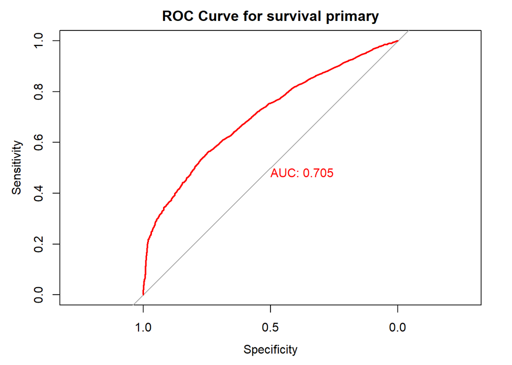

```r
roc_curve <- roc(test_data_primary$hospital_outcome~pred_primary, plot = T, col="red", print.auc = T, main = "ROC Curve for survival primary")
```

As a matter of fact, an Area Under the Curve of 0.705 highlights that the model has a good discriminant capacity, but it can be surely improved - take into account that an AUC = 0.5 means that the model makes random predictions.

```r
optimal_threshold <- coords(roc_curve, "best", best.method = "closest.topleft")
optimal_threshold
```

```
##   threshold specificity sensitivity
## 1 0.9174576   0.6845161   0.6110976
```

```r
opt_pred_primary <- predict(log_survival_primary, test_data_primary, type="response")
opt_class_primary <- ifelse(pred_primary >= optimal_threshold$threshold, 1 , 0)
mse_primary <- mean(opt_class_primary != test_data_primary$hospital_outcome)
mse_primary
```

```
## [1] 0.3837394
```

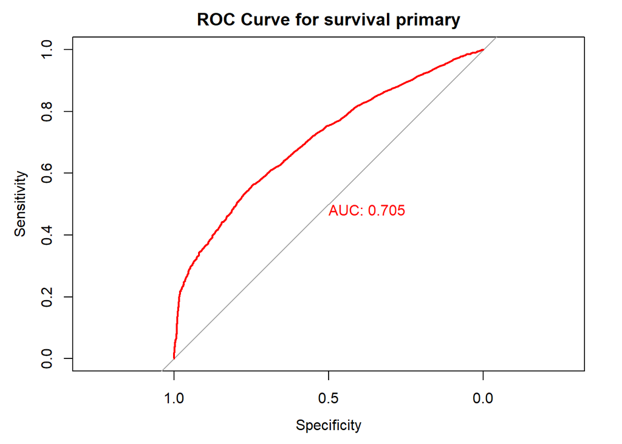

```r
roc_curve <- roc(test_data_primary$hospital_outcome~opt_pred_primary, plot = T, col="red", print.auc = T, main = "ROC Curve for survival primary")
```

```r
str(survival_validation_cohort)
```

```
## tibble [137 × 6] (S3: tbl_df/tbl/data.frame)
##  $ age                 : num [1:137] 20 22 26 33 33 33 35 35 36 36 ...
##  $ sex                 : num [1:137] 0 0 1 1 0 0 0 1 0 1 ...
##  $ count_episode       : num [1:137] 1 1 2 1 1 2 1 1 1 1 ...
##  $ hospital_outcome    : num [1:137] 1 1 0 1 1 0 1 1 1 1 ...
##  $ sex_cat             : chr [1:137] "male" "male" "female" "female" ...
##  $ hospital_outcome_cat: chr [1:137] "alive" "alive" "dead" "alive" ...
```

```r
survival_validation_cohort <- survival_validation_cohort%>%
select(age, sex, count_episode ,hospital_outcome)
```

```r
survival_validation_cohort$sex <- as.factor(survival_validation_cohort$sex)
survival_validation_cohort$count_episode <- as.factor(survival_validation_cohort$count_episode)
survival_validation_cohort$hospital_outcome <- as.factor(survival_validation_cohort$hospital_outcome)
```

```r
head(predictions <- predict(log_survival_primary, newdata = survival_validation_cohort, type="response"), 20)
```

```
##         1         2         3         4         5         6         7         8
## 0.9912884 0.9904838 0.9894190 0.9869391 0.9845544 0.9829752 0.9831385 0.9857386
##         9        10        11        12        13        14        15        16
## 0.9823834 0.9850982 0.9837312 0.9790171 0.9814467 0.9771053 0.9776925 0.9739150
##        17        18        19        20
## 0.9769215 0.9758948 0.9722775 0.9702936
```

```r
class_pred_validation <- ifelse(predictions >= 0.85, 1,0)
(mse_primary <- mean(class_pred_validation != survival_validation_cohort$hospital_outcome))
```

```
## [1] 0.189781
```

```r
class_pred_validation
```

```
##   1   2   3   4   5   6   7   8   9  10  11  12  13  14  15  16  17  18  19  20
##   1   1   1   1   1   1   1   1   1   1   1   1   1   1   1   1   1   1   1   1
##  21  22  23  24  25  26  27  28  29  30  31  32  33  34  35  36  37  38  39  40
##   1   1   1   1   1   1   1   1   1   1   1   1   1   1   1   1   1   1   1   1
##  41  42  43  44  45  46  47  48  49  50  51  52  53  54  55  56  57  58  59  60
##   1   1   1   1   1   1   1   1   1   1   1   1   1   1   1   1   1   1   1   1
##  61  62  63  64  65  66  67  68  69  70  71  72  73  74  75  76  77  78  79  80
##   1   1   1   1   1   1   1   1   1   1   1   1   1   1   1   1   1   1   1   1
##  81  82  83  84  85  86  87  88  89  90  91  92  93  94  95  96  97  98  99 100
##   1   1   1   0   0   1   1   1   1   1   1   1   1   1   1   1   1   1   1   1
## 101 102 103 104 105 106 107 108 109 110 111 112 113 114 115 116 117 118 119 120
##   1   1   1   1   1   1   1   1   1   1   1   1   1   1   1   1   1   1   1   1
## 121 122 123 124 125 126 127 128 129 130 131 132 133 134 135 136 137
##   1   1   1   1   1   1   1   1   1   1   1   1   1   1   1   1   1
```

```r
(confusion_matrix <- table(predicted = class_pred_validation, actual = survival_validation_cohort$hospital_outcome))
```

```
##          actual
## predicted   0   1
##         0   0   2
##         1  24 111
```

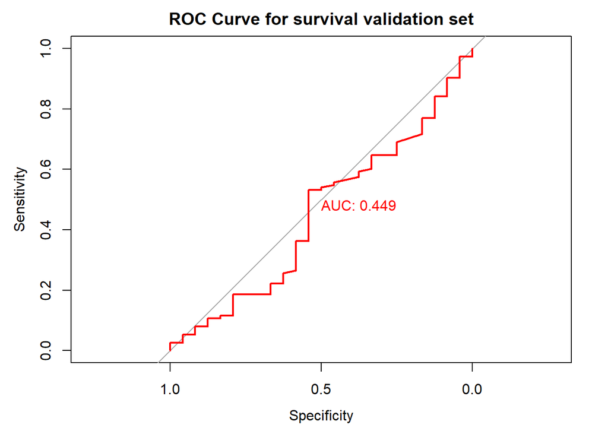

```r
roc_curve <- roc(survival_validation_cohort$hospital_outcome~predictions, plot = T, col="red", print.auc = T, main = "ROC Curve for survival validation set")
```

As previously noticed, it is evident that there is a scarcity of data in the latest ROC Curve computation. Indeed, the AUC is below 0.5, meaning that the model is generating random predictions.  
This kind of difficulty can be avoid by taking into account all the negative outcome from the dataset and just a bounded selection of the positive ones, potentially yielding more favorable results. On the other hand, this approach would fail to represent reality, which is the primary aim.  
Alternative models can be taken into account in order to achieve more coherent results.

# 5 Survival Analysis

Start of the study: 2010-01-01 End of the study: 2011-12-31 The study lasts 2 years

We just take into account right censoring. A subject may be censored due to:

- Loss to follow-up
- Withdrawal from study
- No event by end of fixed study period

```r
# Defining the beginning and the ending dates
start_date <- as.Date("2010-01-01")
end_date <- as.Date("2011-12-31")

# Creating a sequence of dates from start_date to end_date
all_dates <- seq(start_date, end_date, by = "day")

# Setting seed
set.seed(123)

# N. observations
n_obs <- 110204

# Random generation of recovering date
start_dates <- sample(all_dates, n_obs, replace = TRUE)

# Generate a random interval of days for the duration of hospitalization (between 1 and 30 days)
durata_ricovero <- sample(1:30, n_obs, replace = TRUE)

# Calculate the discharge dates by adding the interval of days to the admission date.
end_dates <- start_dates + durata_ricovero

# Ensure that the discharge dates do not exceed the overall end date.
end_dates <- pmin(end_dates, end_date)

# Print the first 10 pairs of admission and discharge dates.
head(dates <- data.frame(start_date = start_dates, end_date = end_dates), 10)
```

```
##    start_date   end_date
## 1  2011-02-19 2011-03-13
## 2  2011-04-08 2011-04-22
## 3  2010-06-28 2010-07-08
## 4  2011-06-10 2011-06-11
## 5  2010-07-14 2010-07-18
## 6  2010-04-28 2010-05-11
## 7  2010-10-26 2010-11-19
## 8  2010-08-17 2010-09-06
## 9  2010-09-01 2010-09-04
## 10 2010-01-14 2010-01-31
```

```r
survival_primary_cohort <- cbind(survival_primary_cohort,dates)
head(survival_primary_cohort)
```

```
##   age sex count_episode hospital_outcome start_date   end_date
## 1  21   1             1                1 2011-02-19 2011-03-13
## 2  20   1             1                1 2011-04-08 2011-04-22
## 3  21   1             1                1 2010-06-28 2010-07-08
## 4  77   0             1                1 2011-06-10 2011-06-11
## 5  72   0             1                1 2010-07-14 2010-07-18
## 6  83   0             1                1 2010-04-28 2010-05-11
```

```r
survival_primary_cohort$duration <- difftime(survival_primary_cohort$start_date,start_date, units="days")
head(survival_primary_cohort)
```

```
##   age sex count_episode hospital_outcome start_date   end_date duration
## 1  21   1             1                1 2011-02-19 2011-03-13 414 days
## 2  20   1             1                1 2011-04-08 2011-04-22 462 days
## 3  21   1             1                1 2010-06-28 2010-07-08 178 days
## 4  77   0             1                1 2011-06-10 2011-06-11 525 days
## 5  72   0             1                1 2010-07-14 2010-07-18 194 days
## 6  83   0             1                1 2010-04-28 2010-05-11 117 days
```

```r
survival_primary_cohort$duration <- as.numeric(survival_primary_cohort$duration)
```

```r
str(survival_primary_cohort)
```

```
## 'data.frame':    110204 obs. of  7 variables:
##  $ age             : num  21 20 21 77 72 83 74 74 69 53 ...
##  $ sex             : Factor w/ 2 levels "0","1": 2 2 2 1 1 1 1 2 1 2 ...
##  $ count_episode   : Factor w/ 5 levels "1","2","3","4",..: 1 1 1 1 1 1 1 1 1 1 ...
##  $ hospital_outcome: Factor w/ 2 levels "0","1": 2 2 2 2 2 2 2 2 2 2 ...
##  $ start_date      : Date, format: "2011-02-19" "2011-04-08" ...
##  $ end_date        : Date, format: "2011-03-13" "2011-04-22" ...
##  $ duration        : num  414 462 178 525 194 117 298 228 243 13 ...
```

```r
survival_primary_cohort$duration <- as.numeric(survival_primary_cohort$duration)
str(survival_primary_cohort)
```

```
## 'data.frame':    110204 obs. of  7 variables:
##  $ age             : num  21 20 21 77 72 83 74 74 69 53 ...
##  $ sex             : Factor w/ 2 levels "0","1": 2 2 2 1 1 1 1 2 1 2 ...
##  $ count_episode   : Factor w/ 5 levels "1","2","3","4",..: 1 1 1 1 1 1 1 1 1 1 ...
##  $ hospital_outcome: Factor w/ 2 levels "0","1": 2 2 2 2 2 2 2 2 2 2 ...
##  $ start_date      : Date, format: "2011-02-19" "2011-04-08" ...
##  $ end_date        : Date, format: "2011-03-13" "2011-04-22" ...
##  $ duration        : num  414 462 178 525 194 117 298 228 243 13 ...
```

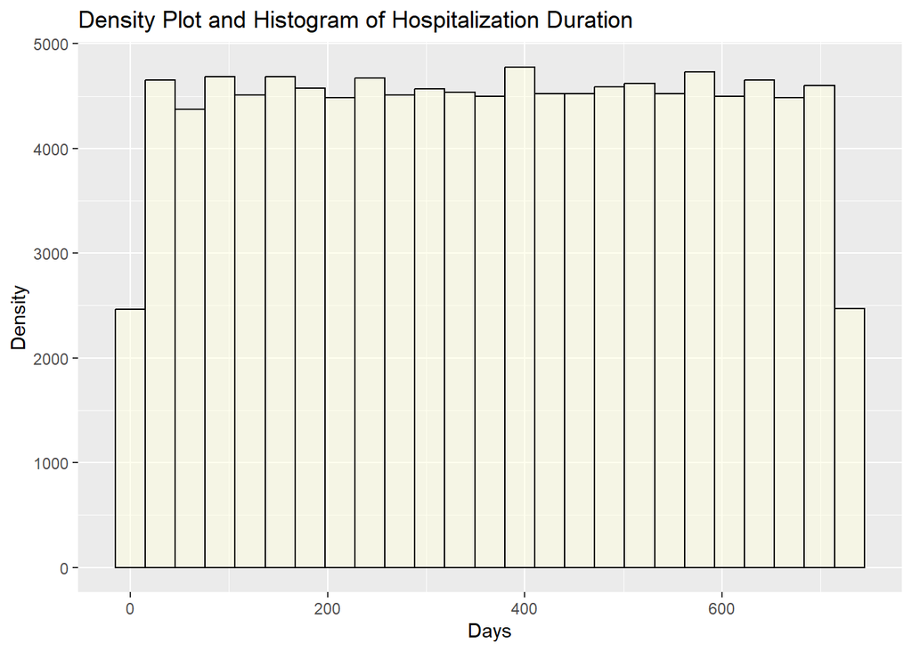

```r
ggplot(data = survival_primary_cohort) +
  geom_histogram(aes(x = duration), bins = 25, fill = "lightyellow", alpha = 0.5, color = "black") +
  labs(x = "Days",
       y = "Density",
       title = "Density Plot and Histogram of Hospitalization Duration")
```

```r
Surv(survival_primary_cohort$duration, survival_primary_cohort$hospital_outcome)[1:10]
```

```
##  [1] 414:1 462:1 178:1 525:1 194:1 117:1 298:1 228:1 243:1  13:1
```

```r
survival_primary_cohort <- survival_primary_cohort%>%
mutate(hospital_outcome=dplyr::recode(hospital_outcome,"0"=1,"1"=0))
```

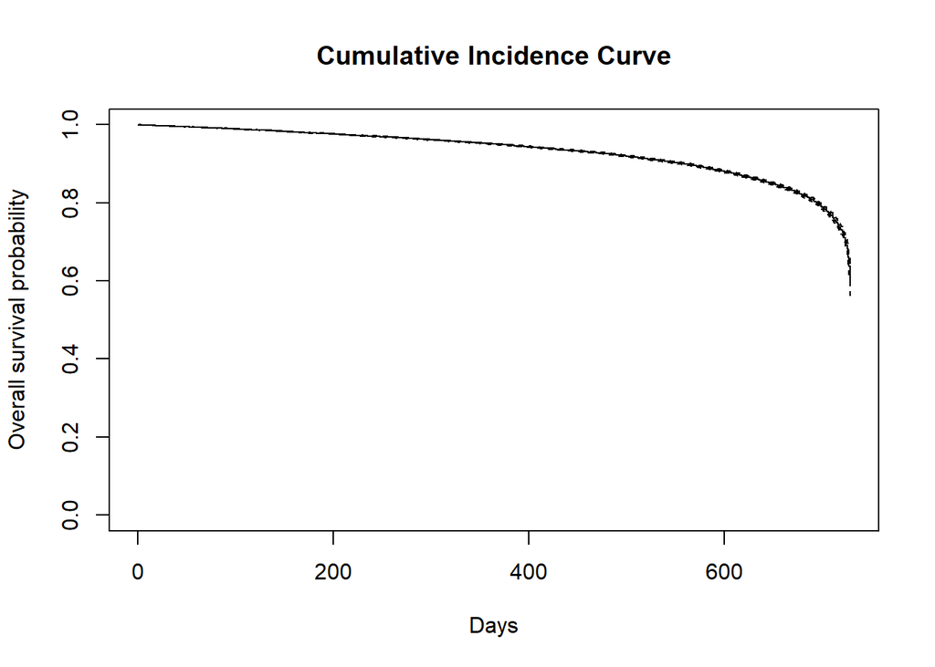

```r
surv_fit <- survfit(Surv(survival_primary_cohort$duration, survival_primary_cohort$hospital_outcome) ~ 1)

plot(surv_fit, xlab = "Days", ylab = "Overall survival probability", main = "Cumulative Incidence Curve")
```

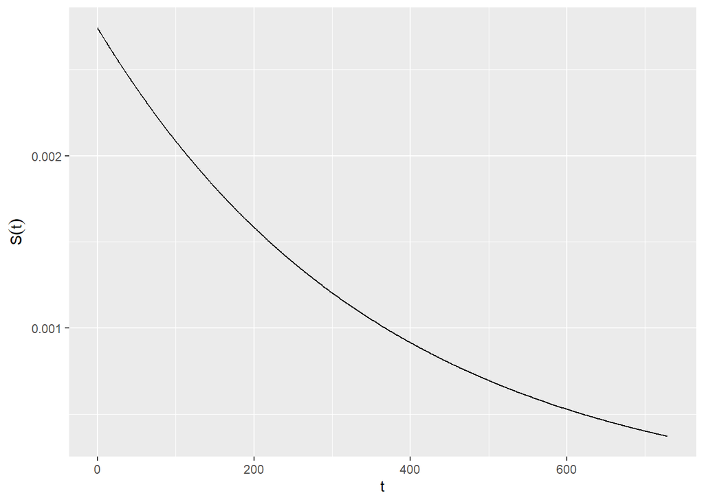

```r
survival_primary_cohort_0 <- survival_primary_cohort%>%
dplyr::filter(hospital_outcome==1)
lambdahat <- mean(survival_primary_cohort_0$duration)^{-1}
survival_primary_cohort_0$par <- dexp(survival_primary_cohort_0$duration, rate = lambdahat)
ggplot(survival_primary_cohort_0) +
  geom_line(aes(x = duration, y = par)) +
  xlab(expression(t)) + ylab(expression(S(t)))
```

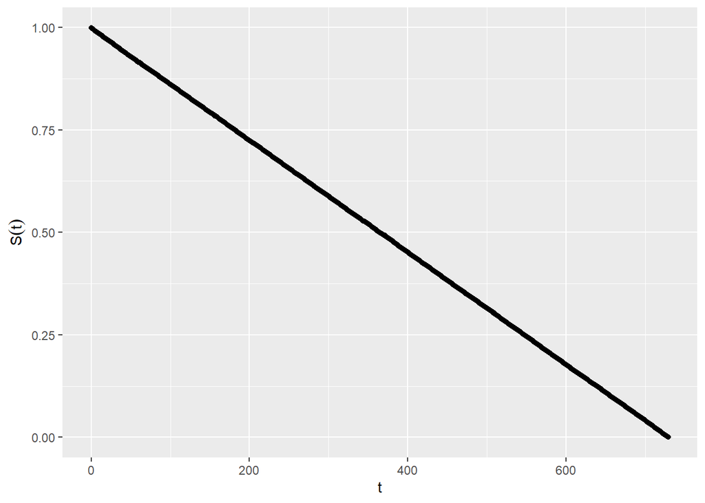

```r
ggplot(survival_primary_cohort) +
  stat_esf(aes(x = duration)) +
  xlab(expression(t)) + ylab(expression(S(t)))
```

```r
s <- Surv(survival_primary_cohort$duration, survival_primary_cohort$hospital_outcome)
sfit <- survfit(s~1)
summary(sfit)
```

```
## Call: survfit(formula = s ~ 1)
##
##  time n.risk n.event survival  std.err lower 95% CI upper 95% CI
##     0 110204      10    1.000 2.87e-05        1.000        1.000
##     1 110049      11    1.000 4.16e-05        1.000        1.000
##     2 109899       9    1.000 4.98e-05        1.000        1.000
##     3 109759      11    1.000 5.82e-05        1.000        1.000
##     4 109588       8    1.000 6.37e-05        0.999        1.000
##     5 109422      13    0.999 7.17e-05        0.999        1.000
##     6 109283       8    0.999 7.62e-05        0.999        1.000
##     7 109132      17    0.999 8.50e-05        0.999        0.999
##     8 108966      14    0.999 9.17e-05        0.999        0.999
##     9 108803      13    0.999 9.75e-05        0.999        0.999
##    10 108634      13    0.999 1.03e-04        0.999        0.999
##    11 108474      12    0.999 1.08e-04        0.999        0.999
```

[output cut: 718 more lines]

```r
sfit
```

```
## Call: survfit(formula = s ~ 1)
##
##           n events median 0.95LCL 0.95UCL
## [1,] 110204   8105     NA      NA      NA
```

## 5.1 Kaplan Meier

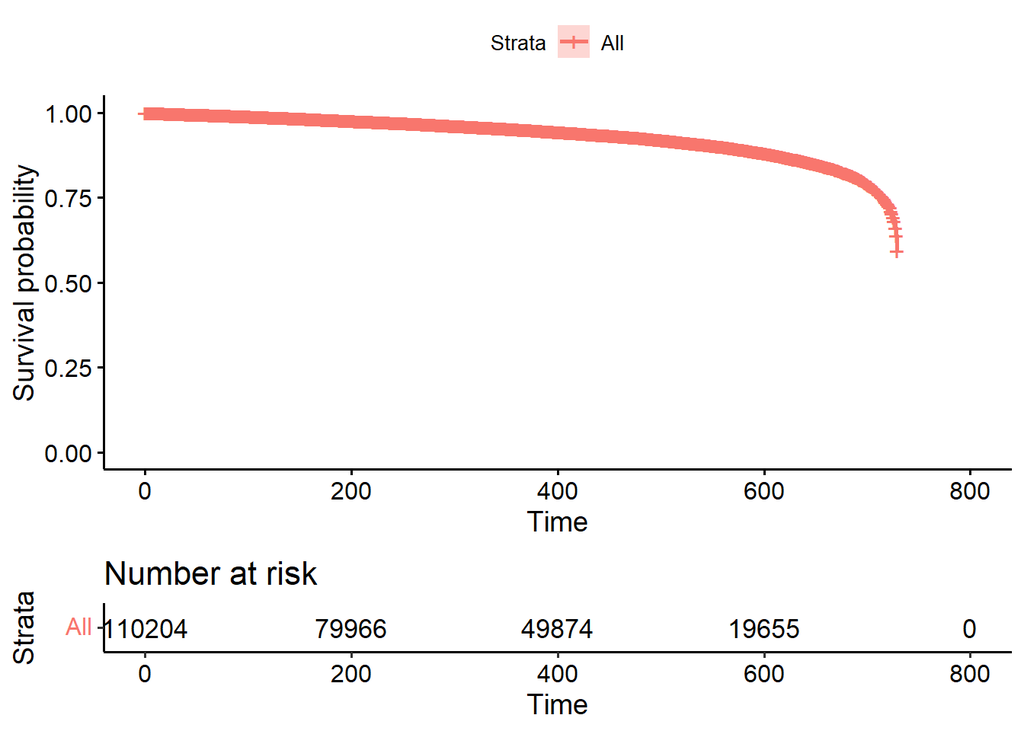

```r
ggsurvplot(fit = sfit, data = survival_primary_cohort, risk.table = TRUE)
```

```r
sfit <- survfit(Surv (duration,hospital_outcome ) ~ sex, data = survival_primary_cohort)
summary(sfit)
```

```
## Call: survfit(formula = Surv(duration, hospital_outcome) ~ sex, data = survival_primary_cohort)
##
##                 sex=0
##  time n.risk n.event survival  std.err lower 95% CI upper 95% CI
##     0  57973       6    1.000 4.23e-05        1.000        1.000
##     1  57885       9    1.000 6.69e-05        1.000        1.000
##     2  57808       3    1.000 7.33e-05        1.000        1.000
##     3  57733       6    1.000 8.46e-05        0.999        1.000
##     4  57641       6    0.999 9.47e-05        0.999        1.000
##     5  57549       5    0.999 1.02e-04        0.999        1.000
##     6  57479       3    0.999 1.07e-04        0.999        1.000
##     7  57402       9    0.999 1.19e-04        0.999        0.999
##     8  57309      10    0.999 1.31e-04        0.999        0.999
##     9  57226       6    0.999 1.38e-04        0.999        0.999
##    10  57145       4    0.999 1.42e-04        0.999        0.999
```

[output cut: 1448 more lines]

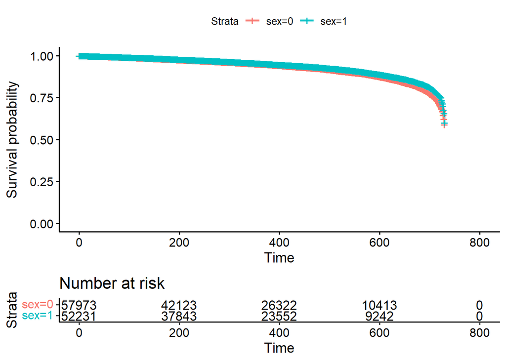

```r
ggsurvplot(fit = sfit, data = survival_primary_cohort,risk.table = TRUE)
```

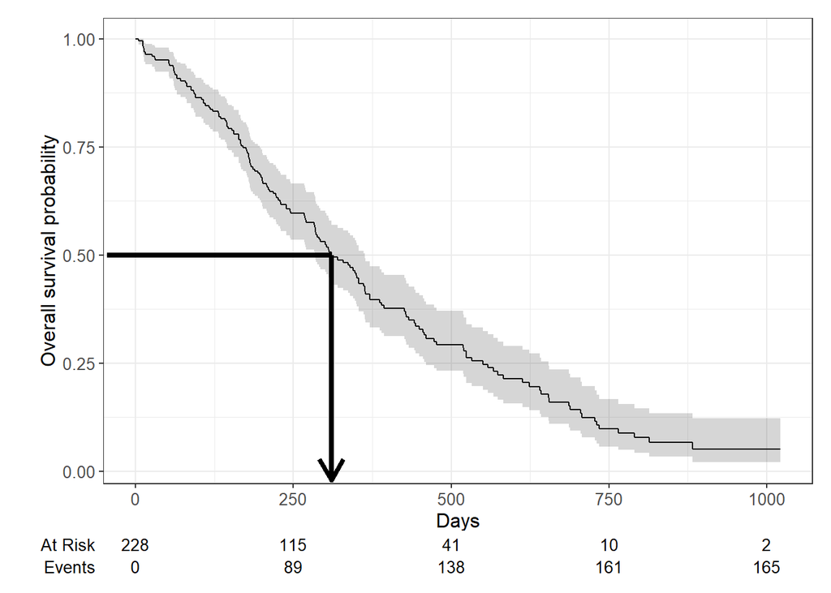

```r
plot_main <-
  survfit2(Surv(time, status) ~ 1, data = lung) %>%
  ggsurvfit() +
  labs(
    x = "Days",
    y = "Overall survival probability"
    ) +
  add_confidence_interval() +
  add_risktable()

plot2 <- plot_main

plot2 <-
  plot_main +
  geom_segment(x = -45, xend = 310, y = 0.5, yend = 0.5,  size = 1.5) +
  geom_segment(x = 310, xend = 310, y = 0.5, yend = -0.02, size = 1.5,
               arrow = arrow(length = unit(0.2, "inches")))

plot2
```

## 5.2 COX MODEL

```r
cox_model <- coxph(Surv(duration, hospital_outcome)~sex, data = survival_primary_cohort)
cox_model
```

```
## Call:
## coxph(formula = Surv(duration, hospital_outcome) ~ sex, data = survival_primary_cohort)
##
##          coef exp(coef) se(coef)      z       p
## sex1 -0.13485   0.87385  0.02238 -6.024 1.7e-09
##
## Likelihood ratio test=36.47  on 1 df, p=1.553e-09
## n= 110204, number of events= 8105
```

```r
model<- survdiff(Surv(duration, hospital_outcome)~sex, data = survival_primary_cohort)
model
```

```
## Call:
## survdiff(formula = Surv(duration, hospital_outcome) ~ sex, data = survival_primary_cohort)
##
##           N Observed Expected (O-E)^2/E (O-E)^2/V
## sex=0 57973     4548     4277      17.2      36.4
## sex=1 52231     3557     3828      19.2      36.4
##
##  Chisq= 36.4  on 1 degrees of freedom, p= 2e-09
```

```r
str(survival_primary_cohort)
```

```
## 'data.frame':    110204 obs. of  7 variables:
##  $ age             : num  21 20 21 77 72 83 74 74 69 53 ...
##  $ sex             : Factor w/ 2 levels "0","1": 2 2 2 1 1 1 1 2 1 2 ...
##  $ count_episode   : Factor w/ 5 levels "1","2","3","4",..: 1 1 1 1 1 1 1 1 1 1 ...
##  $ hospital_outcome: num  0 0 0 0 0 0 0 0 0 0 ...
##  $ start_date      : Date, format: "2011-02-19" "2011-04-08" ...
##  $ end_date        : Date, format: "2011-03-13" "2011-04-22" ...
##  $ duration        : num  414 462 178 525 194 117 298 228 243 13 ...
```

```r
full_model <- coxph(Surv(duration, hospital_outcome)~sex + count_episode + age, data = survival_primary_cohort)
full_model
```

```
## Call:
## coxph(formula = Surv(duration, hospital_outcome) ~ sex + count_episode +
##     age, data = survival_primary_cohort)
##
##                      coef  exp(coef)   se(coef)      z        p
## sex1           -0.1616933  0.8507021  0.0224642 -7.198 6.12e-13
## count_episode2  0.1003605  1.1055694  0.0296456  3.385 0.000711
## count_episode3  0.0434416  1.0443990  0.0512484  0.848 0.396624
## count_episode4  0.0360568  1.0367147  0.0794313  0.454 0.649874
## count_episode5 -0.0877246  0.9160132  0.1219819 -0.719 0.472042
## age             0.0412192  1.0420805  0.0007889 52.251  < 2e-16
##
## Likelihood ratio test=4042  on 6 df, p=< 2.2e-16
## n= 110204, number of events= 8105
```

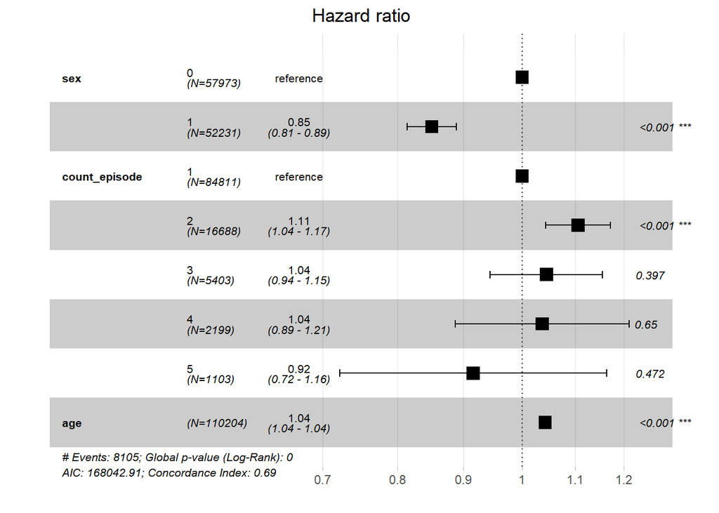

```r
ggforest(full_model, data = survival_primary_cohort)
```

```r
mv_fit <- coxph(Surv(duration, hospital_outcome) ~ sex + age, data = survival_primary_cohort)
cz <- cox.zph(mv_fit)
print(cz)
```

```
##        chisq df    p
## sex     2.51  1 0.11
## age     2.24  1 0.13
## GLOBAL  4.45  2 0.11
```